# Suomalaiset arvostavat nyt enemmän urbaaneja asuinympäristöjä kuin aiemmin

TL;DR: Tiheästi asuttujen alueiden asuntojen hinnat ovat muutamana viime vuotena nousseet harvemmin asuttujen alueiden hintoja nopeammin koko Suomessa ja erityisesti pääkaupunkiseudulla. Tämä on todennäköisesti seurausta siitä, että ihmiset arvostavat nykyään enemmän urbaaneja asuinympäristöjä.

Maailmalla on vallannut alaa uusi urbanismin aalto, jossa ihmiset haluavat muuttaa tiiviisiin kaupunkikeskustoihin omakotitalolähiöiden sijaan (ks esim. http://www.nytimes.com/2014/04/17/opinion/americas-urban-future.html). Korkeasta väestötiheydestä sanotaan olevan monia etuja: Se tarjoaa monipuoliset palvelut, työpaikkojen ja palveluiden hyvän saavutettavuuden, mahdollisuuden rakentaa viihtyisää kävely-ympäristöä ja tehokkaasti toimivan joukkoliikenteen. Lisäksi tiivis rakentaminen säästää viheralueita ja luo edellytykset talouskasvulle mm. sen tähden, että saman alan yritykset saavat lähekkäin sijaitsemisesta kasautumisetuja.

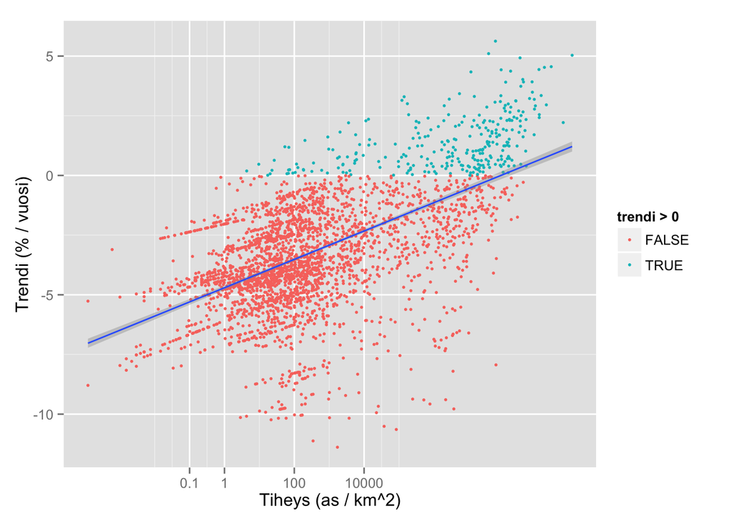

Kuvaajasta nähdään selvästi, että tiheästi asuttujen alueiden hinnat laskevat hitaammin kuin muun Suomen hinnat tai jopa nousevat vielä.

Tilannetta voidaan tarkastella myös yksittäisten kuntien osalta. Alle on kuvattu yhteys väestötiheyden ja lineaarisen hintakehityksen välillä Suomen kymmenen suurimman kaupungin osalta.

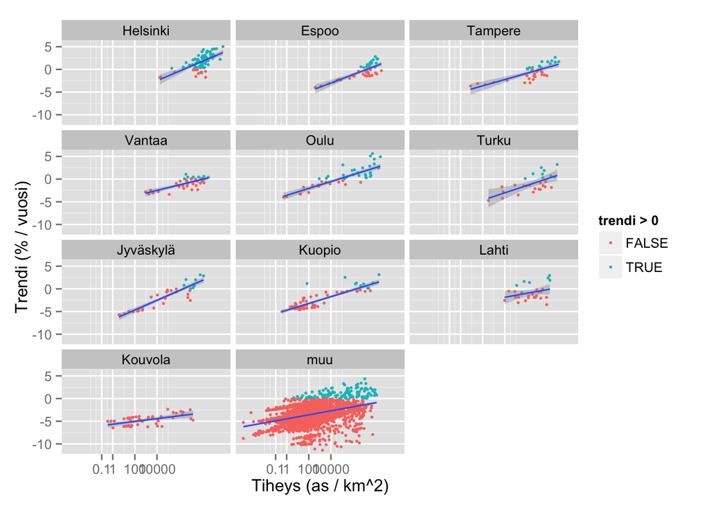